# Entrega 3

Vania Gastulo

2022-05-11

## **TRABAJO EN GRUPO**

### Curso: POL 304 - Estadística para el análisis político 2

### Nombres y apellidos: Vania Nicoll Gastulo Machado

### Código: 20190617

### Semestre 2022-1

======================================================================

###**a. Introducción y objetivos**

El presente estudio busca ser un análisis exploratorio de los factores que afectan la participación de las mujeres en la fuerza laboral. Para toma como unidad de análisis a todos los países del mundo, basandonos en la información que provee el Banco Mundial para el año 2016.

```r
library(rio)
data=import("Data_World_Bank_2016.xlsx")
```

###**b. Explicacion de la variable dependiente y sustentación con literatura de las independientes propuestas.**

```r
names(data)
```

```
##  [1] "Country Name" "Country Code" "FLF"          "WSC"          "ARF"
##  [6] "GDE"          "BSS"          "UET"          "GEE"          "GDP"
## [11] "GFC"          "IVA"          "GEI"          "CDA"
```

```r
data$`Country Name`<-as.factor(data$`Country Name`)
data = data[complete.cases(data$`Country Name`),]
```

```
**Variable Dependiente:**
 - Porcentaje de participación de mujeres en la fuerza laboral (FLF)
```

```r
str(data$FLF)
```

```
##  num [1:217] 19.8 42 19.7 NA NA ...
```

```r
data$FLF<-as.numeric(data$FLF)
data = data[complete.cases(data$FLF),]
summary(data$FLF)
```

```
##    Min. 1st Qu.  Median    Mean 3rd Qu.    Max.
##   7.986  39.060  44.473  41.314  47.343  55.832
```

**Variables Independientes:** 1. Tasa de embarazo adolescente (AFR) 2. Una mujer puede firmar un contrato de la misma forma que un hombre (WSC)

**Adolescent Fertility Rate**

```r
str(data$ARF)
```

```
##  num [1:187] 68.8 20.7 10.4 154.5 63 ...
```

```r
data$ARF<-as.numeric(data$ARF)
data = data[complete.cases(data$ARF),]
summary(data$ARF)
```

```
##     Min.  1st Qu.   Median     Mean  3rd Qu.     Max.
##   0.2864  13.3151  37.9116  47.2944  69.3414 194.0090
```

**Women can sign a contract the same way as a man**

```r
str(data$WSC)
```

```
##  num [1:184] 0 1 0 1 0 0 1 1 1 0 ...
```

```r
data$WSC<-as.factor(data$WSC)
data = data[complete.cases(data$WSC),]
summary(data$WSC)
```

```
##   0   1
## 105  70
```

```r
levels(data$WSC)<-c("NO","SÍ")
summary(data$WSC)
```

```
##  NO  SÍ
## 105  70
```

```r
table(as.numeric(data$WSC))
```

```
##
##   1   2
## 105  70
```

###**c. Analisis de regresión**

##**Primera regresión** Objetivo: Analizar si la variable WSC afecta a nuestra variable dependiente (FLF)

###Prueba de normalidad y correlación#

```r
library(nortest)
lillie.test(data$FLF)
```

```
##
##  Lilliefors (Kolmogorov-Smirnov) normality test
##
## data:  data$FLF
## D = 0.16724, p-value = 5.593e-13
```

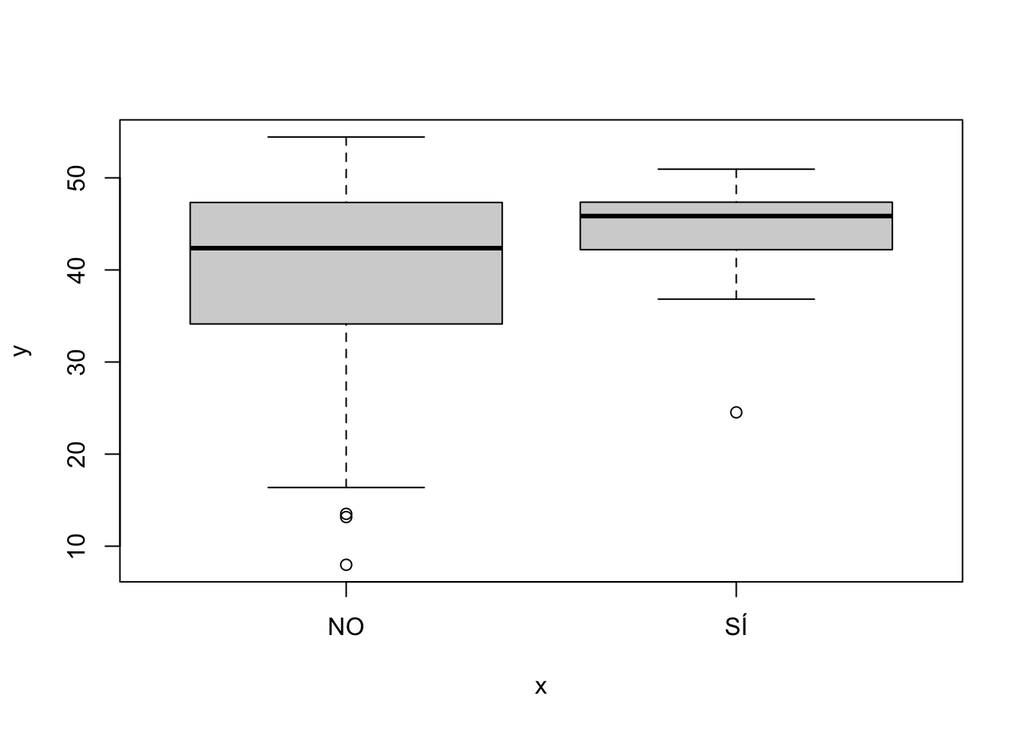

```r
plot(data$WSC,data$FLF)
```

```r
library(nortest)
lillie.test(data$ARF)
```

```
##
##  Lilliefors (Kolmogorov-Smirnov) normality test
##
## data:  data$ARF
## D = 0.13457, p-value = 3.326e-08
```

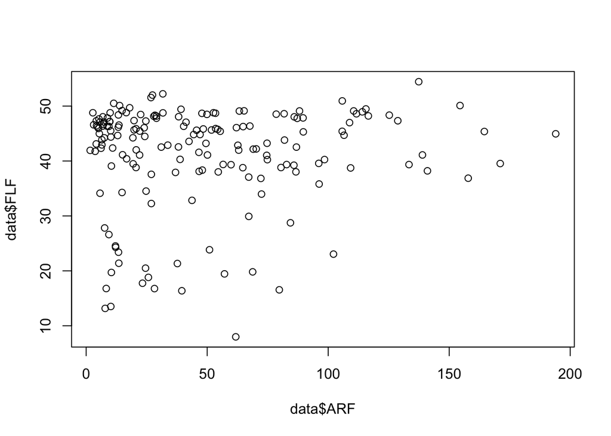

```r
plot(data$ARF,data$FLF)
```

###Regresión lineal simple

```r
Model1=lm(FLF~WSC,data=data)
summary(Model1)
```

```
##
## Call:
## lm(formula = FLF ~ WSC, data = data)
##
## Residuals:
##     Min      1Q  Median      3Q     Max
## -30.875  -3.628   1.930   6.044  15.576
##
## Coefficients:
##             Estimate Std. Error t value Pr(>|t|)
## (Intercept)  38.8606     0.8803  44.143  < 2e-16 ***
## WSCSÍ         5.6404     1.3919   4.052 7.65e-05 ***
## ---
## Signif. codes:  0 '***' 0.001 '**' 0.01 '*' 0.05 '.' 0.1 ' ' 1
##
## Residual standard error: 9.021 on 173 degrees of freedom
## Multiple R-squared:  0.08669,    Adjusted R-squared:  0.08141
## F-statistic: 16.42 on 1 and 173 DF,  p-value: 7.652e-05
```

```r
Model2=lm(FLF~ARF,data=data)
summary(Model2)
```

```
##
## Call:
## lm(formula = FLF ~ ARF, data = data)
##
## Residuals:
##     Min      1Q  Median      3Q     Max
## -33.391  -2.846   3.377   6.473  11.575
##
## Coefficients:
##             Estimate Std. Error t value Pr(>|t|)
## (Intercept) 40.16183    1.10341  36.398   <2e-16 ***
## ARF          0.01964    0.01736   1.132    0.259
## ---
## Signif. codes:  0 '***' 0.001 '**' 0.01 '*' 0.05 '.' 0.1 ' ' 1
##
## Residual standard error: 9.404 on 173 degrees of freedom
## Multiple R-squared:  0.007347,   Adjusted R-squared:  0.001609
## F-statistic: 1.281 on 1 and 173 DF,  p-value: 0.2594
```

###Regresión Gaussiana (lineal múltiple)

```r
Model3=lm(FLF~ARF+WSC, data=data)
summary(Model3)
```

```
##
## Call:
## lm(formula = FLF ~ ARF + WSC, data = data)
##
## Residuals:
##     Min      1Q  Median      3Q     Max
## -31.066  -3.765   2.497   5.856  14.345
##
## Coefficients:
##             Estimate Std. Error t value Pr(>|t|)
## (Intercept) 36.65718    1.30001  28.198  < 2e-16 ***
## ARF          0.03873    0.01698   2.281   0.0238 *
## WSCSÍ        6.44220    1.41955   4.538 1.06e-05 ***
## ---
## Signif. codes:  0 '***' 0.001 '**' 0.01 '*' 0.05 '.' 0.1 ' ' 1
##
## Residual standard error: 8.913 on 172 degrees of freedom
## Multiple R-squared:  0.1135, Adjusted R-squared:  0.1032
## F-statistic: 11.01 on 2 and 172 DF,  p-value: 3.166e-05
```

### Comparación de Modelos

```r
library(stargazer)
stargazer(Model1,Model2,Model3, type ="text")
```

```
##
## =======================================================================================
##                                             Dependent variable:
##                     -------------------------------------------------------------------
##                                                     FLF
##                               (1)                   (2)                   (3)
## ---------------------------------------------------------------------------------------
## WSCSÍ                      5.640***                                    6.442***
##                             (1.392)                                     (1.420)
##
## ARF                                                0.020                0.039**
##                                                   (0.017)               (0.017)
##
## Constant                   38.861***             40.162***             36.657***
##                             (0.880)               (1.103)               (1.300)
##
## ---------------------------------------------------------------------------------------
## Observations                  175                   175                   175
## R2                           0.087                 0.007                 0.113
## Adjusted R2                  0.081                 0.002                 0.103
## Residual Std. Error    9.021 (df = 173)      9.404 (df = 173)      8.913 (df = 172)
## F Statistic         16.421*** (df = 1; 173) 1.281 (df = 1; 173) 11.010*** (df = 2; 172)
## =======================================================================================
## Note:                                                       *p<0.1; **p<0.05; ***p<0.01
```

###**d. Analisis de cluster**  
(tus propias variables + otras del grupo): SOLO GRAFICA CON escalamiento multidimensional (mapa de puntos coloreado)

```r
data$GDE<-as.numeric(data$GDE)
data = data[complete.cases(data$GDE),]
summary(data$GDE)
```

```
##    Min. 1st Qu.  Median    Mean 3rd Qu.    Max.
##   1.190   3.440   4.403   4.468   5.402  10.652
```

```r
data$BSS<-as.numeric(data$BSS)
data = data[complete.cases(data$BSS),]
summary(data$BSS)
```

```
##    Min. 1st Qu.  Median    Mean 3rd Qu.    Max.
##   4.157  32.833  75.659  65.166  96.584 100.000
```

```r
data$UET<-as.numeric(data$UET)
data = data[complete.cases(data$UET),]
summary(data$UET)
```

```
##    Min. 1st Qu.  Median    Mean 3rd Qu.    Max.
##   0.534   4.120   5.900   7.939   9.670  26.540
```

```r
list(names(data))
```

```
## [[1]]
##  [1] "Country Name" "Country Code" "FLF"          "WSC"          "ARF"
##  [6] "GDE"          "BSS"          "UET"          "GEE"          "GDP"
## [11] "GFC"          "IVA"          "GEI"          "CDA"
```

```r
data_c = data[,c(1,3,4,5)]
```

```r
library(readr)
str(data_c)
```

```
## 'data.frame':    121 obs. of  4 variables:
##  $ Country Name: Factor w/ 217 levels "Afghanistan",..: 1 2 3 6 8 9 12 13 16 18 ...
##  $ FLF         : num  19.8 42 19.7 50.1 42 ...
##  $ WSC         : Factor w/ 2 levels "NO","SÍ": 1 2 1 2 1 1 2 2 1 1 ...
##  $ ARF         : num  68.8 20.7 10.4 154.5 63 ...
```

```r
summary(data_c)
```

```
##       Country Name      FLF        WSC          ARF
##  Afghanistan:  1   Min.   :17.75   NO:74   Min.   :  3.092
##  Albania    :  1   1st Qu.:39.54   SÍ:47   1st Qu.: 19.415
##  Algeria    :  1   Median :45.41           Median : 45.623
##  Angola     :  1   Mean   :42.72           Mean   : 53.066
##  Argentina  :  1   3rd Qu.:47.85           3rd Qu.: 81.792
##  Armenia    :  1   Max.   :54.44           Max.   :171.083
##  (Other)    :115
```

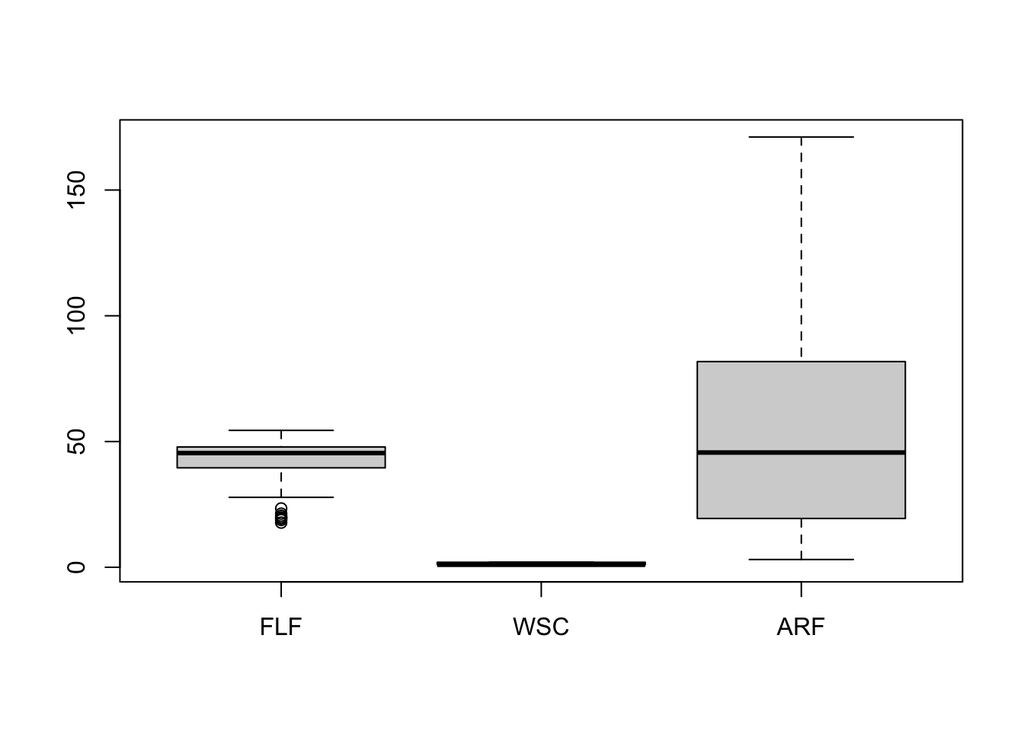

```r
boxplot(data_c[,-1])
```

```r
library(BBmisc)
```

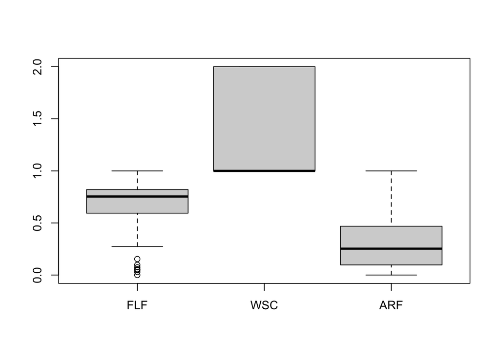

```r
boxplot(normalize(data_c[,-1],method='range',range=c(0,1)))
```

```r
data_c[,-1]=normalize(data_c[,-1],method='standardize')
data_c=data_c[complete.cases(data_c),]

summary(data_c)
```

```
##       Country Name      FLF          WSC          ARF
##  Afghanistan:  1   Min.   :-3.2346   NO:74   Min.   :-1.2195
##  Albania    :  1   1st Qu.:-0.4118   SÍ:47   1st Qu.:-0.8212
##  Algeria    :  1   Median : 0.3488           Median :-0.1816
##  Angola     :  1   Mean   : 0.0000           Mean   : 0.0000
##  Argentina  :  1   3rd Qu.: 0.6640           3rd Qu.: 0.7010
##  Armenia    :  1   Max.   : 1.5178           Max.   : 2.8800
##  (Other)    :115
```

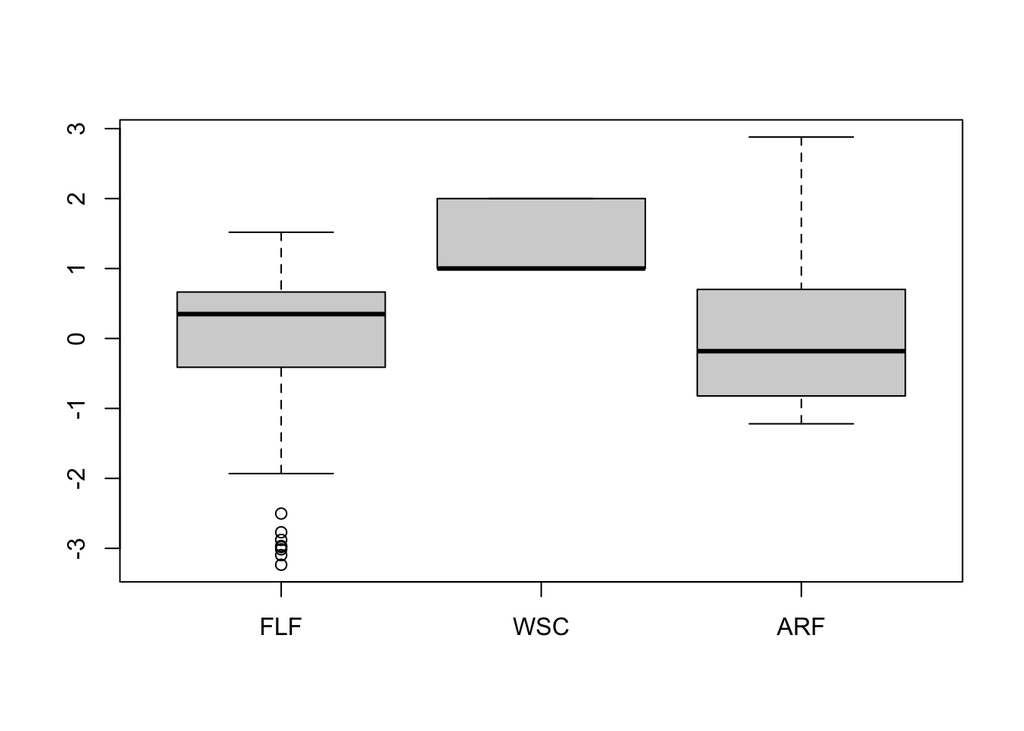

```r
boxplot(normalize(data_c[,-1],method='standardize'))
```

###Correlaciones

```r
data_C = data[,c(1,3,4,5,6,7,8)]
```

```r
library(polycor)
hetcor(data_C[,-1])
```

```
##
## Two-Step Estimates
##
## Correlations/Type of Correlation:
##         FLF        WSC        ARF        GDE        BSS        UET
## FLF       1 Polyserial    Pearson    Pearson    Pearson    Pearson
## WSC  0.3058          1 Polyserial Polyserial Polyserial Polyserial
## ARF  0.0856    -0.3161          1    Pearson    Pearson    Pearson
## GDE 0.03382     0.1813    -0.3593          1    Pearson    Pearson
## BSS -0.2078     0.5222    -0.5832     0.3666          1    Pearson
## UET  -0.131    0.02577    -0.1363     0.2486     0.0643          1
##
## Standard Errors:
##         FLF     WSC     ARF     GDE     BSS
## FLF
## WSC  0.1232
## ARF 0.09049  0.1039
## GDE 0.09105  0.1117 0.07951
## BSS 0.08726 0.08609  0.0604 0.07902
## UET  0.0896  0.1167 0.08947 0.08558 0.09078
##
## n = 121
##
## P-values for Tests of Bivariate Normality:
##           FLF      WSC       ARF       GDE       BSS
## FLF
## WSC 8.128e-05
## ARF 0.0003833  0.05299
## GDE   0.02082  0.09368  0.003584
## BSS 4.398e-06 0.002938   0.01257  0.002395
## UET 8.724e-05 7.79e-06 1.249e-05 0.0008831 1.044e-07
```

```r
data_C$FLF=-1*data_C$FLF
hetcor(data_C[,-1])
```

```
##
## Two-Step Estimates
##
## Correlations/Type of Correlation:
##          FLF        WSC        ARF        GDE        BSS        UET
## FLF        1 Polyserial    Pearson    Pearson    Pearson    Pearson
## WSC  -0.3058          1 Polyserial Polyserial Polyserial Polyserial
## ARF  -0.0856    -0.3161          1    Pearson    Pearson    Pearson
## GDE -0.03382     0.1813    -0.3593          1    Pearson    Pearson
## BSS   0.2078     0.5222    -0.5832     0.3666          1    Pearson
## UET    0.131    0.02577    -0.1363     0.2486     0.0643          1
##
## Standard Errors:
##         FLF     WSC     ARF     GDE     BSS
## FLF
## WSC  0.1232
## ARF 0.09049  0.1039
## GDE 0.09105  0.1117 0.07951
## BSS 0.08726 0.08609  0.0604 0.07902
## UET  0.0896  0.1167 0.08947 0.08558 0.09078
##
## n = 121
##
## P-values for Tests of Bivariate Normality:
##           FLF      WSC       ARF       GDE       BSS
## FLF
## WSC 8.128e-05
## ARF 0.0003833  0.05299
## GDE   0.02082  0.09368  0.003584
## BSS 4.398e-06 0.002938   0.01257  0.002395
## UET 8.724e-05 7.79e-06 1.249e-05 0.0008831 1.044e-07
```

##Clusterización

Calcular distancia

```r
str(data_C)
```

```
## 'data.frame':    121 obs. of  7 variables:
##  $ Country Name: Factor w/ 217 levels "Afghanistan",..: 1 2 3 6 8 9 12 13 16 18 ...
##  $ FLF         : num  -19.8 -42 -19.7 -50.1 -42 ...
##  $ WSC         : Factor w/ 2 levels "NO","SÍ": 1 2 1 2 1 1 2 2 1 1 ...
##  $ ARF         : num  68.8 20.7 10.4 154.5 63 ...
##  $ GDE         : num  3.51 3.96 7.34 2.75 5.55 ...
##  $ BSS         : num  39.4 97.2 78.6 22.3 76.8 ...
##  $ UET         : num  11.16 15.42 10.2 7.41 8.11 ...
```

```r
library(cluster)
D <- daisy(data_C, metric = "gower")
```

```r
set.seed(123)
pam.resultado=pam(D,4,cluster.only = F)

#nueva columna
data_C$pam=pam.resultado$cluster
```

```r
aggregate(.~ pam, data=data_C,mean)
```

```
##   pam Country Name       FLF      WSC      ARF      GDE      BSS       UET
## 1   1    107.77778 -20.95149 1.000000 29.84444 4.458127 74.51991 11.564444
## 2   2    116.15556 -44.48549 2.000000 35.79348 4.921910 84.98233  8.182556
## 3   3     97.90323 -45.53052 1.064516 96.77614 3.130221 20.97506  5.698516
## 4   4    103.61111 -43.53098 1.000000 42.82436 5.253222 76.11123  8.656611
```

### Estrategia Aglomerativa

```r
set.seed(123)
library(factoextra)
```

```r
library(ggplot2)

res.agnes<- hcut(D, k = 4,hc_func='agnes',hc_method = "ward.D")

data_C$agnes=res.agnes$cluster
```

```r
aggregate(.~ agnes, data=data_C,mean)
```

```
##   agnes Country Name       FLF WSC      ARF      GDE      BSS      UET      pam
## 1     1     105.3095 -37.45005   1 44.07513 4.613413 79.72214 7.687952 3.261905
## 2     2     107.5926 -45.88676   2 17.41220 5.190145 97.42192 8.090741 2.000000
## 3     3     118.6500 -43.06753   2 71.01472 4.311282 61.48984 8.082700 2.100000
## 4     4     101.9062 -46.74301   1 83.73326 3.988719 21.14365 8.049656 3.218750
```

###Visualización del Conglomerado - Dendograma

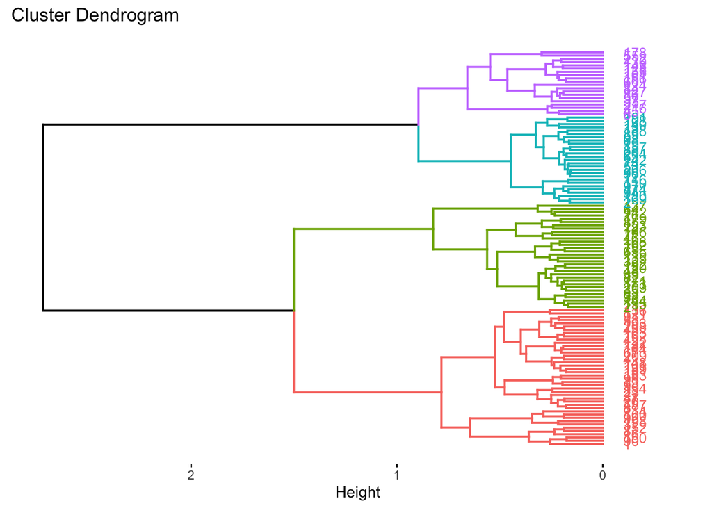

```r
fviz_dend(res.agnes, cex = 0.7, horiz = T)
```

```r
table(data_C$pam,data_C$agnes,dnn = c('Particion','Aglomeracion'))
```

```
##          Aglomeracion
## Particion  1  2  3  4
##         1  9  0  0  0
##         2  0 27 18  0
##         3  4  0  2 25
##         4 29  0  0  7
```

###Estrategia Divisiva

```r
set.seed(123)
res.diana <- hcut(D, k = 4,hc_func='diana')
data_C$diana=res.diana$cluster
```

```r
aggregate(.~ diana, data=data_C,mean)
```

```
##   diana Country Name       FLF      WSC      ARF      GDE      BSS       UET
## 1     1    103.20000 -38.17535 1.000000 39.56900 4.948162 80.79583  8.881825
## 2     2    116.15556 -44.48549 2.000000 35.79348 4.921910 84.98233  8.182556
## 3     3     99.19355 -45.85841 1.064516 90.32241 3.122061 22.23940  4.359742
## 4     4    106.40000 -43.70003 1.000000 85.51648 6.313122 27.93121 20.389400
##        pam    agnes
## 1 3.325000 1.150000
## 2 2.000000 2.400000
## 3 3.096774 3.548387
## 4 3.400000 4.000000
```

###Visualización del Conglomerado - Dendograma

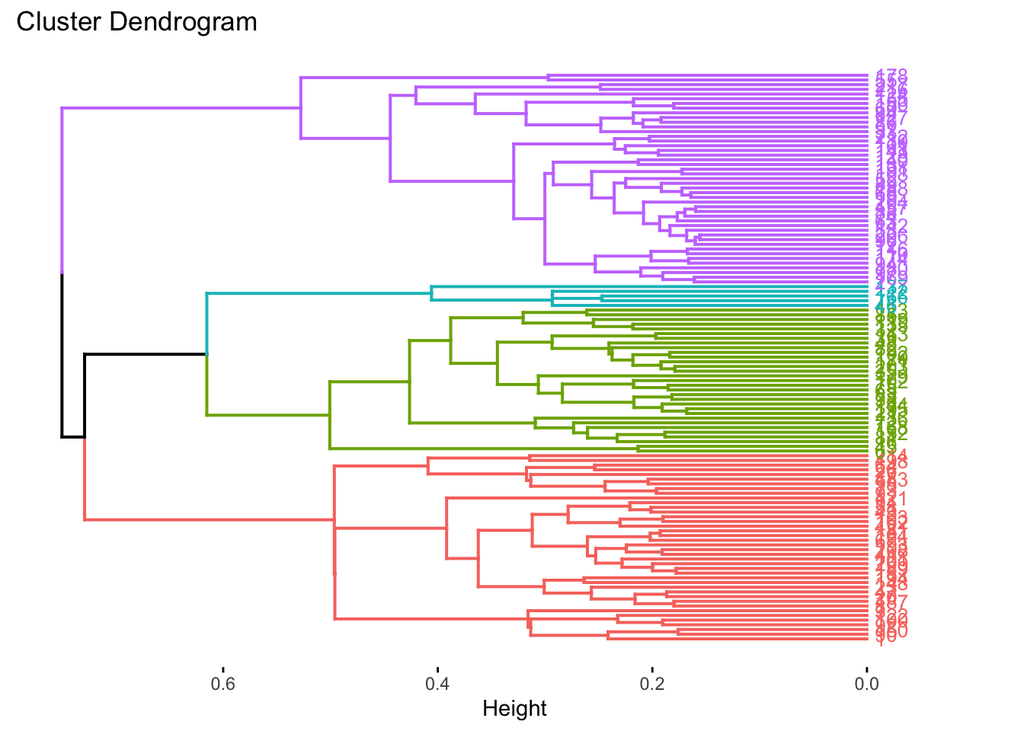

```r
fviz_dend(res.diana, cex = 0.7, horiz = T)
```

##Comparación de Clusters

```r
table(data_C$diana,data_C$agnes,dnn = c('Division','Aglomeracion'))
```

```
##         Aglomeracion
## Division  1  2  3  4
##        1 38  0  0  2
##        2  0 27 18  0
##        3  4  0  2 25
##        4  0  0  0  5
```

##Estrategia Basada en Densidad

###Mapa de casos

```r
proyeccion = cmdscale(D, k=2,add = T)
```

```r
data_C$dim1 <- proyeccion$points[,1]
data_C$dim2 <- proyeccion$points[,2]
```

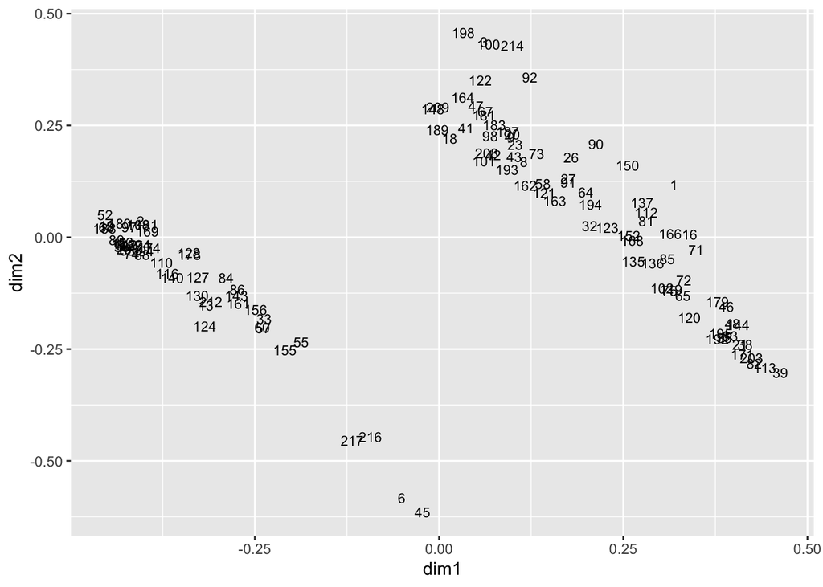

```r
base= ggplot(data_C,aes(x=dim1, y=dim2,label=row.names(data_C)))
base + geom_text(size=3)
```

- Pam

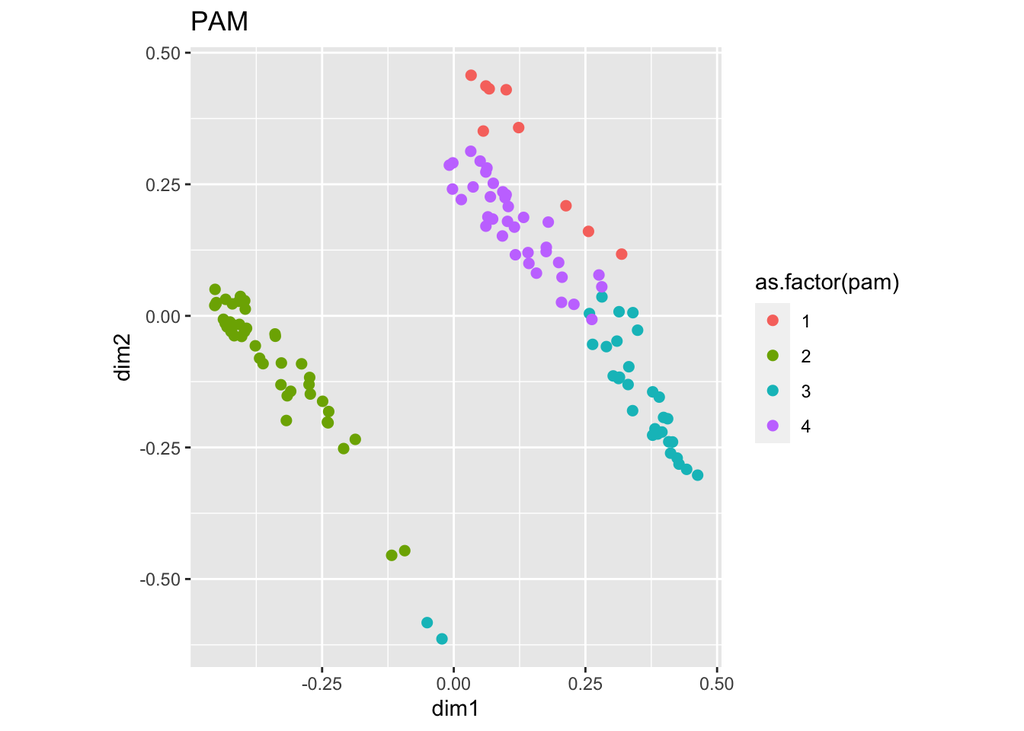

```r
base= ggplot(data_C,aes(x=dim1, y=dim2)) +  coord_fixed()
base + geom_point(size=2, aes(color=as.factor(pam)))  + labs(title = "PAM")
```

-Agnes

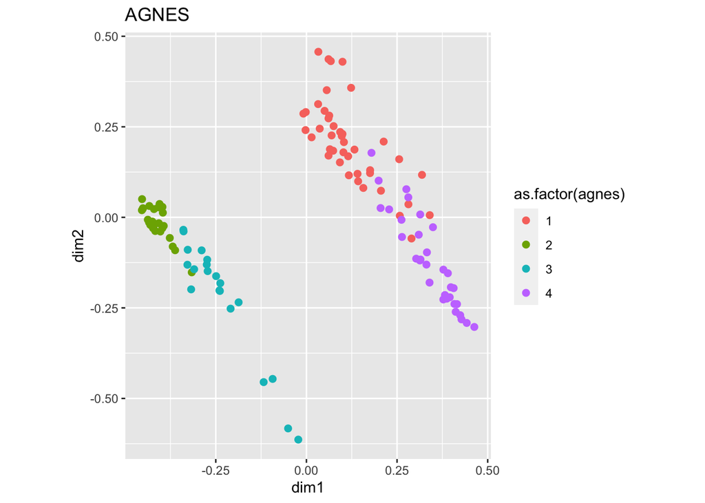

```r
base + geom_point(size=2, aes(color=as.factor(agnes))) + labs(title = "AGNES")
```

- Diana

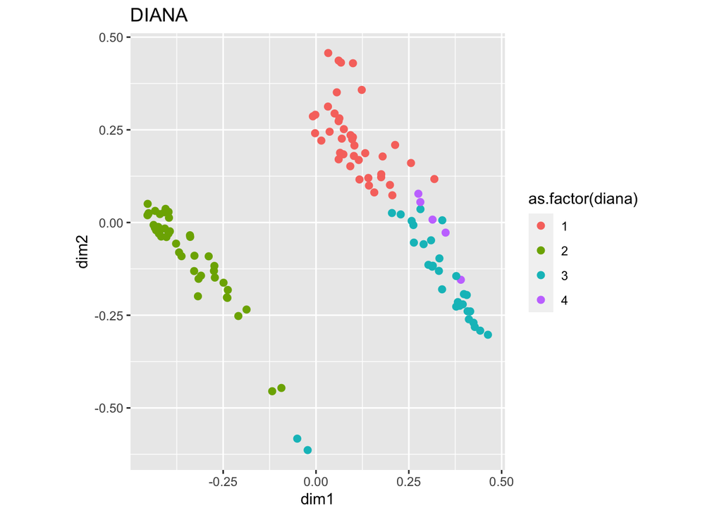

```r
base + geom_point(size=2, aes(color=as.factor(diana))) + labs(title = "DIANA")
```

```r
g.dist.cmd = daisy(data_C[,c('dim1','dim2')], metric = 'euclidean')
```

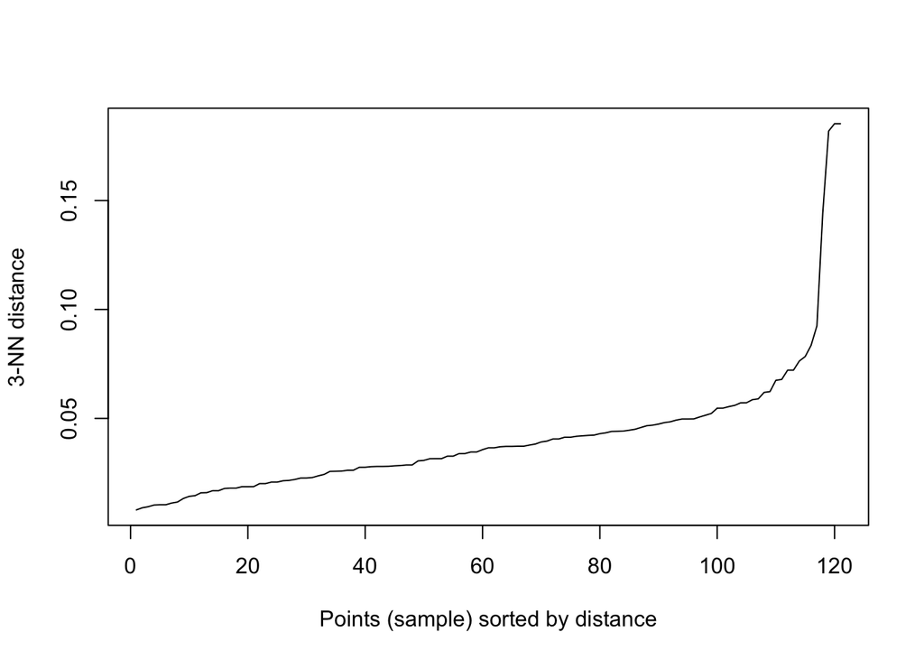

```r
library(dbscan)
kNNdistplot(g.dist.cmd, k=3)
```

```r
library(fpc)
db.cmd = fpc::dbscan(g.dist.cmd, eps=0.065, MinPts=3,method = 'dist')
```

```r
db.cmd
```

```
## dbscan Pts=121 MinPts=3 eps=0.065
##        0  1 2  3
## border 5  0 0  2
## seed   0 43 4 67
## total  5 43 4 69
```

```r
data_C$db=as.factor(db.cmd$cluster)
```

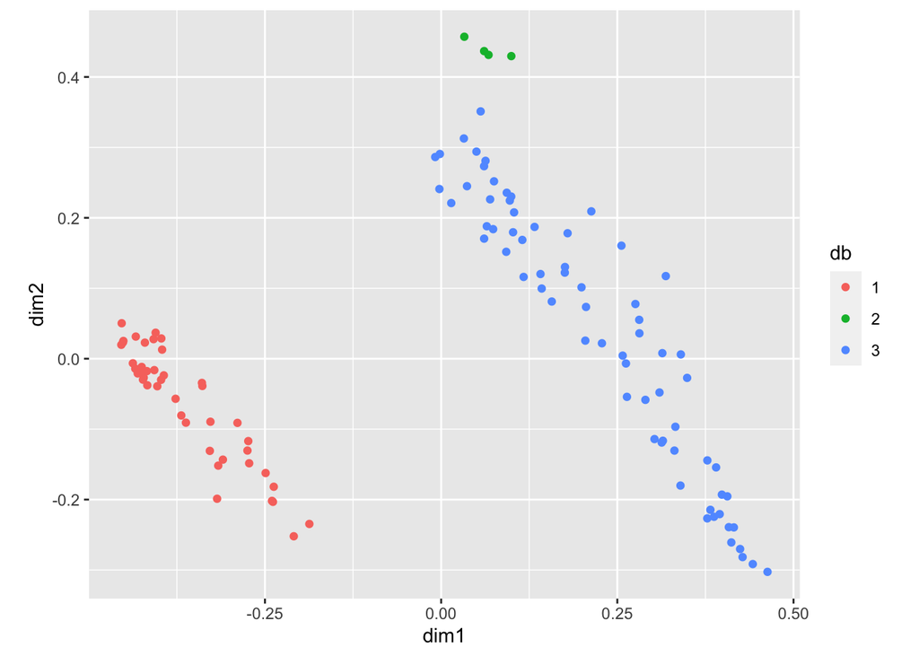

```r
library(ggrepel)
base= ggplot(data_C[data_C$db!=0,],aes(x=dim1, y=dim2)) + coord_fixed()

dbplot= base + geom_point(aes(color=db))

dbplot + geom_point(data=data_C[data_c$db==0,],
                    shape=0)
```

###Proceso del Analisis Factorial Exploratorio (EFA)

1.Matriz de correlación:

```r
dontselect=c("Country")
select=setdiff(names(data_C),dontselect)
Data=data_C[,select]
```

```r
library(polycor)
corMatrix=polycor::hetcor(Data)$correlations
```

2. Explorar correlaciones:

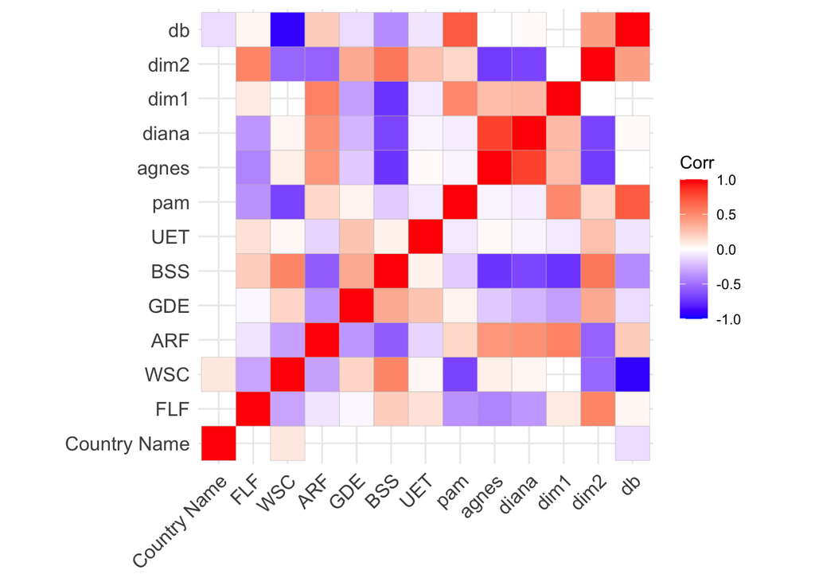

```r
library(ggcorrplot)
ggcorrplot(corMatrix)
```

```r
library(psych)
psych::KMO(corMatrix)
```

```
## Kaiser-Meyer-Olkin factor adequacy
## Call: psych::KMO(r = corMatrix)
## Overall MSA =  NA
## MSA for each item =
## Country Name          FLF          WSC          ARF          GDE          BSS
##           NA           NA           NA           NA           NA           NA
##          UET          pam        agnes        diana         dim1         dim2
##           NA           NA           NA           NA           NA           NA
##           db
##           NA
```

```r
cortest.bartlett(corMatrix,n=nrow(Data))$p.value>0.05
```

```
## [1] NA
```